# TWAS Notebook

## Introduction

This notebook keeps track of information when performing the TWAS analysis. The process basically imports genotype-expression and expression-phenotype weights and performs predictions. We mainly concern TWAS study for scizophrenia data.

The relevant packages of the TWAS process are:

```r
library('plink2R')
library("optparse")
```

## Datasets

### 1. Summary GWAS statistics for szizophrenia:

```r
sumstat = read.table("FUSION/PGC2.SCZ.sumstats",head=T,as.is=T)
```

This file is provided by PCG. The summary statustics maintains the basic information of scizophrenia-related loci and associated allele information. The basic property of the file is:

```r
dim(sumstat)
```

```
[1] 1083014       6
```

```r
head(sumstat)
```

|  | SNP | A1 | A2 | N | CHISQ | Z |
| --- | --- | --- | --- | --- | --- | --- |
| 1 | rs6671356 | C | T | 70100 | 0.172612905 | 0.41546709 |
| 2 | rs6604968 | G | A | 70100 | 0.291125789 | 0.53956074 |
| 3 | rs4970405 | A | G | 70100 | 0.102204514 | 0.31969441 |
| 4 | rs12726255 | G | A | 70100 | 0.312418296 | 0.55894391 |
| 5 | rs4970409 | G | A | 70100 | 0.052422685 | 0.22896001 |
| 6 | rs17160824 | G | A | 70100 | 0.001078645 | 0.03284273 |

This dataframe contains information on 1083014 SNPs. It has 6 columns containing the following information:

| SNP | A1 | A2 | Z |
| --- | --- | --- | --- |
| SNP id | Major Allele | Minor Allele | z-score of the linear regression coefficient, $\frac{\beta}{\sigma_\beta}$, signed with A1 |

We can obtain a manhattan plot by using this data:

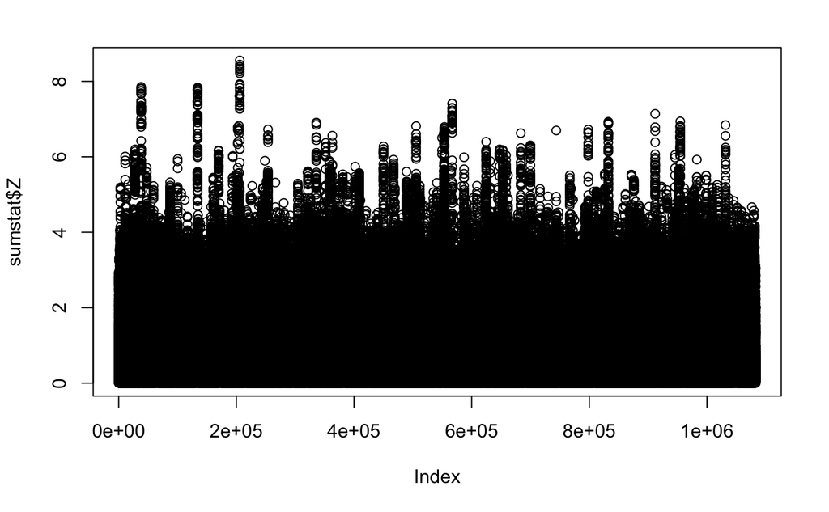

```r
plot(sumstat$Z)
```

The data has not been pruned or threshoded. We can see high polygenicity from the graph.

### 2. LD reference data

```r
chromosome = 22
genos = read_plink(paste('FUSION/LDREF/1000G.EUR.',chromosome,sep=''),impute="avg")
```

The genos data is in PLINK format. For each chromosome, it contains three different objects: bed, fam and bim.

##### 2.1 bed (PLINK binary biallelic genotype table)

```r
dim(genos$bed)
```

```
[1]   489 17489
```

```r
head(genos$bed[,1:8])
```

```
                rs9617528 rs4911642 rs7287144 rs5748662 rs5994034 rs4010554 rs4010558 rs3954571
HG00096:HG00096         0         0         1         1         0         1         1         2
HG00097:HG00097         0         0         0         0         1         0         0         1
HG00099:HG00099         0         0         1         1         0         1         1         1
HG00101:HG00101         1         1         1         2         0         1         1         1
HG00102:HG00102         0         1         1         1         0         1         1         0
HG00103:HG00103         0         0         1         1         0         1         1         1
```

##### 2.2 bim (PLINK extended MAP file)

```r
dim(genos$bim)
```

```
[1] 17489     6
```

```r
head(genos$bim)
```

|  | V1 | V2 | V3 | V4 | V5 | V6 |
| --- | --- | --- | --- | --- | --- | --- |
| 1 | 22 | rs9617528 | 0.0595758 | 16061016 | C | T |
| 2 | 22 | rs4911642 | 2.1274578 | 16504399 | C | T |
| 3 | 22 | rs7287144 | 2.2521052 | 16886873 | G | A |
| 4 | 22 | rs5748662 | 2.2551908 | 16892858 | A | G |
| 5 | 22 | rs5994034 | 2.2558359 | 16894090 | T | C |
| 6 | 22 | rs4010554 | 2.2559285 | 16894264 | A | C |

This dataframe contains information of the corresponding SNPs. It has 6 columns containing the following information:

| V1 | V2 | V3 | V4 | V5 | V6 |
| --- | --- | --- | --- | --- | --- |
| chromosome number | SNP id | SNP position | base pair coordinate | Allele 1 | Allele 2 |

Note that the allele 1 and allele 2 are not necessarily major and minor. So the files must be adjusted according to the summary statistics file.

##### 2.3 fam (PLINK sample information file)

```r
dim(genos$fam)
```

```
[1] 489   6
```

```r
head(genos$fam)
```

|  | V1 | V2 | V3 | V4 | V5 | V6 |
| --- | --- | --- | --- | --- | --- | --- |
| 1 | HG00096 | HG00096 | 0 | 0 | 0 | -9 |
| 2 | HG00097 | HG00097 | 0 | 0 | 0 | -9 |
| 3 | HG00099 | HG00099 | 0 | 0 | 0 | -9 |
| 4 | HG00101 | HG00101 | 0 | 0 | 0 | -9 |
| 5 | HG00102 | HG00102 | 0 | 0 | 0 | -9 |
| 6 | HG00103 | HG00103 | 0 | 0 | 0 | -9 |

This dataset contains the family relations data for the 489 samples. This is not relevant to our analysis and many relational data are missing.

### 3. Weight Data

```r
wgtlist = read.table('FUSION/WEIGHTS/GTEx.Whole_Blood.pos',head=T,as.is=T)
dim(wgtlist)
```

```
[1] 2057    5
```

```r
head(wgtlist)
```

|  | WGT | ID | CHR | P0 | P1 |
| --- | --- | --- | --- | --- | --- |
| 1 | GTEx.Whole_Blood/GTEx.Whole_Blood.ENSG00000176022.3.B3GALT6.wgt.RDat | B3GALT6 | 1 | 1167629 | 1170421 |
| 2 | GTEx.Whole_Blood/GTEx.Whole_Blood.ENSG00000169972.7.PUSL1.wgt.RDat | PUSL1 | 1 | 1243947 | 1246451 |
| 3 | GTEx.Whole_Blood/GTEx.Whole_Blood.ENSG00000272004.1.RP11-345P4.10.wgt.RDat | RP11-345P4.10 | 1 | 1590786 | 1594063 |
| 4 | GTEx.Whole_Blood/GTEx.Whole_Blood.ENSG00000189339.7.SLC35E2B.wgt.RDat | SLC35E2B | 1 | 1592939 | 1624167 |
| 5 | GTEx.Whole_Blood/GTEx.Whole_Blood.ENSG00000149527.13.PLCH2.wgt.RDat | PLCH2 | 1 | 2357419 | 2436965 |
| 6 | GTEx.Whole_Blood/GTEx.Whole_Blood.ENSG00000157870.10.FAM213B.wgt.RDat | FAM213B | 1 | 2517930 | 2520479 |

This is the genotype-expression data for whole-blood tissues provided by GTEx. The file gives us a list of different weight files tagged by their respective chromosome.

We take a specific wgt file for our example.

```r
wgt.file = paste("FUSION/WEIGHTS","/",wgtlist$WGT[1],sep='')
load(wgt.file)
```

Loading the file gives us a wgt.matrix as well as a snps dataset.

```r
dim(snps)
```

```
[1] 220   6
```

```r
head(snps)
```

|  | V1 | V2 | V3 | V4 | V5 | V6 |
| --- | --- | --- | --- | --- | --- | --- |
| 1 | 1 | rs3094315 | 0 | 752566 | G | A |
| 2 | 1 | rs3131972 | 0 | 752721 | A | G |
| 3 | 1 | rs3131969 | 0 | 754182 | A | G |
| 4 | 1 | rs1048488 | 0 | 760912 | C | T |
| 5 | 1 | rs3115850 | 0 | 761147 | T | C |
| 6 | 1 | rs2286139 | 0 | 761732 | C | T |

```r
dim(wgt.matrix)
```

```
[1] 220   3
```

```r
head(wgt.matrix)
```

```
              top1     lasso        enet
rs3094315 1.045378 0.0000000 0.000000000
rs3131972 1.201693 0.0000000 0.000000000
rs3131969 1.361755 0.0000000 0.000000000
rs1048488 2.048423 0.0000000 0.008606025
rs3115850 2.137297 0.0123505 0.042496640
rs2286139 1.323480 0.0000000 0.000000000
```